# Ponto 3 - Relascopia e Método de Bitterlich

Gabriel Agostini Orso

Data de Publicação

28 de março de 2026

# 1 Preâmbulo

**AvisoAviso**

Antes de prosseguir, o leitor deve estar ciente de que o material aqui utilizado foi elaborado com o único objetivo de estudo pessoal, portanto muitas passagens são fruto de conhecimento e interpretação pessoal. No entanto, ainda assim esse texto faz uso extensivo da literatura científica apresentada ao fim do trabalho, mas **por ser material pessoal de estudo** muitas passagens não fazem a devida citação das obras consultadas, tal qual se esperaria de trabalhos científicos.

Além isso, não foram utilizadas ferramentas de inteligência artificial como *chatGPT*, *Gemini*, *Manus* ou outras para a construção do texto. Toda a sequência lógica, exemplos, entendimentos e escrita são de responsabilidade do autor.

Com essas condições em mente, espero que esse material seja oportuno. Boa leitura.

# 2 Introdução

## 2.1 Conceito e origem do termo

A relascopia constitui uma técnica de amostragem florestal que se diferencia por não exigir a demarcação física de parcelas, permitindo a estimativa direta da área basal por hectare com base em princípios geométricos e probabilísticos. Trata-se de um método de amostragem do tipo probabilidade proporcional ao tamanho (PPS), em que a chance de uma árvore ser incluída na amostra é proporcional à sua área seccional, expressa em função do diâmetro à altura do peito (DAP).

O termo “relascopia” origina-se do instrumento óptico denominado *relascope*, desenvolvido pelo engenheiro florestal austríaco Walter Bitterlich, na década de 1940. A proposta de Bitterlich representou um marco na mensuração florestal ao substituir o delineamento de parcelas fixas por uma abordagem baseada em seleção angular, a partir de um ponto de amostragem. Por meio do emprego de um ângulo visual fixo, torna-se possível identificar as árvores “incluídas” ou “excluídas” da amostra com base em sua projeção aparente, considerando sua distância ao ponto de observação.

## 2.2 Visão geral do método de Bitterlich

A principal finalidade da relascopia é a obtenção de estimativas rápidas e confiáveis da área basal por unidade de área, geralmente hectares, sendo particularmente indicada para florestas com árvores de médio a grande porte, onde a instalação e medição de parcelas fixas demandaria elevado esforço operacional. Além disso, a técnica se mostra eficiente em inventários contínuos, áreas de difícil acesso ou levantamentos preliminares, fornecendo dados relevantes com menor custo e tempo.

## 2.3 Importância da relascopia na amostragem florestal

Do ponto de vista da engenharia florestal, a relascopia destaca-se por aliar praticidade e precisão, contribuindo para o planejamento e a tomada de decisão em manejos sustentáveis. Por se tratar de uma metodologia fundamentada em princípios geométricos, sua aplicação requer domínio técnico na utilização dos instrumentos específicos, bem como compreensão de seus pressupostos e limitações.

# 3 O Método de Bitterlich

## 3.1 Histórico: inventado por Walter Bitterlich em 40

Os inventários florestais fundamentam-se essencialmente em dois métodos de amostragem: a amostragem com área fixa e a amostragem com raio variável. A primeira modalidade, caracterizada por parcelas de formato circular, quadrado ou retangular, tem sido amplamente utilizada há mais de um século, especialmente em inventários contínuos. Já o sistema de raio variável, introduzido por Walter Bitterlich em 1947, revolucionou as técnicas de mensuração florestal e recebeu diversas denominações ao longo do tempo, como Ponto de Amostragem Horizontal, Amostragem de Raio Variável, Amostragem por Contagem Angular (ACA), Estação, Prova de Numeração Angular (PNA) e Relascopia.

Inicialmente, o método foi operacionalizado mediante o uso de uma simples bitola angular, sendo a mais conhecida denominada Barra de Bitterlich. Essas bitolas, embora funcionais, apresentavam limitações significativas em terrenos acidentados, uma vez que seu uso em tais condições demandava correções que tornavam o processo consideravelmente mais demorado e complexo.

Diante dessa limitação, Bitterlich dedicou-se ao desenvolvimento de um instrumento capaz de superar esse obstáculo. Em 1949, ele cunhou o termo *Relascopia*, cuja etimologia deriva do latim *Rela* (contagem) e do grego *Skopein* (olhar). Essa nomenclatura revela-se extremamente apropriada para expressar a essência do método, que consiste fundamentalmente em avaliar a área basal por meio da observação e contagem.

Pouco tempo após a publicação de sua teoria em 1947, Bitterlich patenteou, em 1950, o Relascópio de Espelho (*Spiegel-Relaskop*), instrumento que corrige automaticamente as distâncias horizontais em terrenos não planos. É importante ressaltar que, antes de chegar ao protótipo definitivo do relascópio que posteriormente receberia seu nome, o desenvolvimento do instrumento passou por diversos protótipos intermediários, denominados *Pendelrelaskop*.

Bitterlich incorporou ao Relascópio escalas adicionais que possibilitavam a mensuração de outras variáveis comumente avaliadas nos inventários florestais, tornando o instrumento ainda mais versátil e atrativo para os profissionais da área. Posteriormente, devido às limitações de ângulos disponíveis em seu primeiro Relascópio, ele desenvolveu as escalas para o Relascópio de Banda Larga, que, além de oferecer inúmeras possibilidades de ângulos, apresentava modificações nas escalas complementares, proporcionando ainda mais alternativas para medições como alturas e diâmetros ao longo do tronco.

Reconhecendo o potencial do Relascópio para medir diâmetros a diferentes alturas, procedimento acurado para pequenas distâncias, mas limitado para maiores distâncias devido a dificuldades operacionais, Bitterlich desenvolveu, em meados da década de 1970, o Telerelascópio. Esse instrumento, essencialmente um dendrômetro, pode executar todas as funções dos Relascópios convencionais, mas sua concepção foi direcionada principalmente para a medição de diâmetros à distância. Um telescópio acoplado ao dispositivo permite aproximar visualmente o diâmetro distante, possibilitando ao operador realizar medições acuradas tanto do diâmetro quanto da altura.

A amostragem de raio variável introduzida por Bitterlich em 1947 gerou considerável polêmica entre os pesquisadores da época, pois o método proposto permitia estimar a área basal por unidade de área sem a necessidade de estabelecer uma unidade de amostra física ou medir diâmetros individualmente, procedimentos até então considerados indispensáveis no tradicional sistema de área fixa.

O conceito do ponto de amostragem horizontal para estimativa da área basal, divulgado por Bitterlich, foi intensamente discutido por Keen em 1950 e, principalmente, por Grosenbaugh em 1952, 1955 e 1958. Este último difundiu o método entre os profissionais florestais americanos, demonstrando que a bitola angular poderia ser utilizada para selecionar árvores-amostra com probabilidade proporcional a determinados elementos de tamanho. Grosenbaugh também postulou a teoria do ponto de amostragem para obter estimativas não tendenciosas de volume, frequência de árvores, crescimento e altura, amostrando árvores com probabilidade proporcional ao tamanho (*probability proportional to size* - PPS).

Conforme destacado por Husch *et al.* (1982), o conceito original do método de contagem angular foi inquestionavelmente desenvolvido por Bitterlich em 1947. No entanto, os trabalhos de Grosenbaugh, embora enfatizassem a amostragem por pontos horizontais, abrangeram integralmente a teoria da amostragem PPS, fornecendo a base para a confirmação da teoria. Tanto as contribuições de Bitterlich quanto as de Grosenbaugh caracterizam-se por sua excepcional originalidade, constituindo verdadeiros marcos históricos no campo da mensuração florestal.

Desde a proposição de sua teoria em 1947, Bitterlich tem continuamente divulgado e aprimorado seu método, acrescentando inúmeras alternativas que o tornaram significativamente mais completo e aplicável, além de desenvolver instrumentos que evoluíram da simples bitola angular inicial até o sofisticado Telerelascópio, bem como métodos e técnicas que facilitaram sua operacionalização. Consequentemente, tornou-se possível obter estimativas complexas e eficientes por meio desses avanços.

Ao longo do meio século transcorrido desde a proposição da teoria de Bitterlich, inúmeros pesquisadores em todo o mundo estudaram, discutiram, aplicaram, debateram e compararam esta metodologia com outras abordagens. Para ilustrar a relevância desta teoria, Thomson e Deitschman (1959) relataram que, no período de 1947 a 1959, existiam 140 referências bibliográficas sobre o assunto. Labau (1967) adicionou mais 207 referências até 1965 e, segundo Bitterlich (1984), constavam no *Abstract*, de 1973 a 1978, outras 89 pesquisas relevantes sobre o tema.

## 3.2 Considerações sobre as notações utilizadas

Antes de maiores aprofundamentos no método de Bitterlich, é preciso comentar a notação utilizada. Há historicamente uma falta de concordância na atribuição de símbolos matemáticos para quantidades calculadas na área de manejo florestal, e na relascopia não seria diferente.

Algumas dessas diferenças são pequenas e de fácil interpretação, como a utilização de $d$ ou $DAP$ para diâmetro. Entretanto, outras podem causar confusão ao comparar diferentes literaturas. É o caso do símbolo $K$, que pode ter diferentes significados a depender da literatura utilizada (Tabela 1). Essa temática está em recente discussão na área, que culminou em uma definição supostamente consolidada para termos da área em forma de publicação (Silva *et al*., 2022), e que utiliza $K$ como fator de área basal.

Tabela 1: Exemplos de utilização do símbolo $K$ na relascopia a depender dos autores.

| Autor | Definição | Interpretação |
| --- | --- | --- |
| Péllico Netto & Brena (1997) | $K = \dfrac{d}{L}$ | Constante de abertura angular |
| Finger (2006) | $K = 2500\left(\dfrac{d}{L}\right)^2$ | Fator de Área Basal |
| Silva *et al.* (2022) | $K = 2500\left(\dfrac{d_m}{l}\right)^2$ | Fator de Área Basal |

Ainda assim, será adotada a notação utilizada por Péllico Netto & Brena (1997), pois é senso comum que é uma das literaturas mais utilizadas no Brasil. No mais, cada símbolo também será devidamente apresentado ao longo da discussão.

## 3.3 Princípios da relascopia

A relascopia fundamenta-se em princípios geométricos simples, porém elegantes, que permitem a seleção de árvores com base em sua área seccional sem a necessidade de medição direta de distâncias ou de delimitação de áreas. O conceito central reside na utilização de um ângulo crítico fixo, a partir do qual determina-se se uma árvore deve ou não ser incluída na amostra (Figura 1).

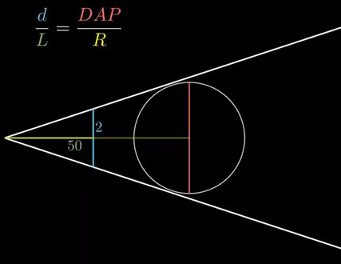

Figura 1: Relação entre o ângulo de visada e o diâmetro e distância da árvore alvo.

Veja que, mantendo o ângulo fixo, a decisão de uma árvore entrar ou não na amostra depende da relação entre seu tamanho ($DAP$) e distância ($R$) do observador. Isso é o mesmo que avaliar se $\dfrac{DAP}{R}$ passa em um critério de inclusão. Cada árvore cujo diâmetro aparente ultrapassa a largura angular definida pelo instrumento de medição é considerada incluída. Caso contrário, é classificada como excluída. Esse critério se baseia na projeção da largura da árvore em relação à sua distância ao ponto de amostragem, formando um triângulo retângulo cujo seno do ângulo é diretamente proporcional ao diâmetro e inversamente proporcional à distância da árvore.

### 3.3.1 Critério de inclusão $DAP/R = 2\sin(\theta/2)$

De forma analítica, o critério de inclusão pode ser expresso por:

$$\frac{DAP}{R} > 2\sin\left(\frac{\theta}{2}\right)$$

Onde $DAP$ é o diâmetro medido a 1,3 m acima do solo, $R$ é a distância do ponto de amostragem até o centro da árvore e $\theta$ é o ângulo formado na abertura de visada.

A definição desse ângulo, no entanto, é a grande ideia por trás do pensamento de Bitterlich. Como já mencionado, Bitterlich estava disposto a encontrar um meio de estimar a área basal da floresta de forma confiável, rápida e sem a necessidade de delimitar parcelas, o que garantiria celeridade na amostragem. Sua ideia surgiu com a premissa de: “Dada uma árvore com tal $DAP$, qual deve ser a área de uma parcela circular para que a área basal seja $1\ \text{m}^2/\text{ha}$?”.

### 3.3.2 Igualando à $1\ \text{m}^2/\text{ha}$

Seja uma parcela de inventário circular com certo raio $R$, composta por apenas uma única árvore situada no limite da parcela, isto é, a distância do centro da parcela até o centro da árvore é igual ao raio da parcela (Figura 2).

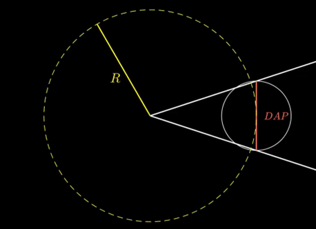

Figura 2: Ideia de área proporcional ao tamanho da árvore.

A área basal dessa parcela é dada por

$$G = \frac{10000}{\text{Área Parcela}}\sum_{i=1}^{n} g_i = \frac{10000}{\text{Área Parcela}}\sum_{i=1}^{n}\frac{DAP_i^2\pi}{4}$$

Onde $G$ é a área basal em $\text{m}^2/\text{ha}$, $10000/\text{Área Parcela}$ é o fator de escala da área da parcela em $\text{m}^2$ para hectares, e $g_i$ é a área transversal da $i$-ésima das $n$ árvores da parcela, tal que $i = 1, 2, \ldots, n$; $DAP_i$ é o diâmetro medido a 1,3 m acima do solo, em metros.

Como há somente uma árvore na parcela, então o somatório se resume a um único indivíduo. Além disso, a área de um círculo é dada por $A_{circ} = \pi R^2$. Portanto,

$$G = \frac{10000}{A_{circ}}\frac{DAP^2\pi}{4}
= \frac{10000}{\pi R^2}\frac{DAP^2\pi}{4}
= \frac{10000}{4}\frac{DAP^2}{R^2}
= 2500\left(\frac{DAP}{R}\right)^2$$

Portanto, a área basal da parcela vale essa quantia, e como ela foi definida para $1\ \text{m}^2/\text{ha}$, então

$$G = 1\ \text{m}^2/\text{ha} = 2500\left(\frac{DAP}{R}\right)^2
\tag{1}$$

$$\frac{1}{2500} = \left(\frac{DAP}{R}\right)^2$$

$$\frac{DAP}{R} = \sqrt{\frac{1}{2500}} = \frac{\sqrt{1}}{\sqrt{2500}} = \frac{1}{50} = 0{,}02$$

Esse resultado implica que, para uma parcela circular que possui uma única árvore representar $1\ \text{m}^2/\text{ha}$, então a razão entre $DAP$ e $R$ precisa ser igual a $0{,}02$. Na verdade, precisa ser igual ou maior que $0{,}02$, pois uma razão maior que isso implica que a árvore está mais para dentro da parcela do que no caso limite, de acordo com a Figura 2. Em outras palavras, uma árvore com relação maior que a proposta implica que ela está dentro de uma parcela que terá $1\ \text{m}^2/\text{ha}$ de área basal. Caso a relação seja menor, então ela está fora da parcela e não compõe a amostra.

Walter Bitterlich notou que essa razão pode ser facilmente conferida por meio de uma mira e um ângulo de visada. Para isso, ele construiu uma pequena barra de madeira, chamada de Barra de Bitterlich, com 50 cm de comprimento ($L = 50$). Em uma das pontas havia uma pequena mira, e na outra ponta uma pequena abertura de 1 cm de largura ($d = 1$). Algumas fontes apontam 100 cm de comprimento e 2 cm de largura, mas o princípio se mantém, de forma que a relação entre a abertura $d$ e o comprimento $L$ fosse igual a $0{,}02$, pois $\dfrac{d}{L} = \dfrac{1}{50} = 0{,}02$.

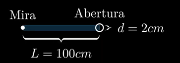

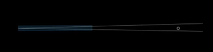

Figura 3: Princípio da Barra de Bitterlich.

Dessa forma, era possível “mirar” em uma determinada árvore, na altura do seu DAP, e conferir se a relação entre $\dfrac{DAP}{R}$ era maior ou menor que $\dfrac{d}{L}$ simplesmente avaliando se o DAP da árvore era maior que a mira, ou se a árvore ficava totalmente contida dentro da visada da mira. Com isso, era possível determinar se a árvore fazia parte da amostra ou não.

A relação $\dfrac{DAP}{R} = \dfrac{d}{L} = \dfrac{1}{50}$ é chamada de $K$, e é importante lembrar que é essa relação que garante que uma única árvore na parcela represente uma área basal de $1\ \text{m}^2/\text{ha}$, pois a área da parcela é escalada para atingir tal quantia. Veja que, nesse exemplo, a área basal foi arbitrariamente definida em $1\ \text{m}^2/\text{ha}$, o que implica no Resultado 1 que

$$G = 1 = 2500\left(\frac{1}{50}\right)^2$$

Onde $\dfrac{1}{50}$ é a relação $\dfrac{d}{L} = K$.

### 3.3.3 FAB

Porém, outros valores de área basal podem ser definidos, o que implica outros valores de $K$. Assim, o Resultado 1 pode ser generalizado para diferentes áreas basais, ou, na linguagem da área, outros Fatores de Área Basal (FAB), resultando em

$$FAB = 2500\left(\frac{d}{L}\right)^2 = 2500K^2
\tag{2}$$

Onde $FAB$ é o Fator de Área Basal e $K$ é a relação entre abertura e distância formada pelo ângulo crítico adotado.

A Tabela 2 traz diferentes fatores de área basal e seus respectivos valores da constante $K$ e ângulo de abertura.

Tabela 2: Fatores de Área Basal, relação $K$ e respectivos ângulos de abertura.

| Fator de Área Basal ($\text{m}^2/\text{ha}$) | $K$ | Ângulo de abertura ($\theta$) |
| --- | --- | --- |
| 1 | $\dfrac{1}{50} = 0{,}02$ | $\theta = 1^\circ08'45''$ |
| 2 | $\dfrac{\sqrt{2}}{50} = 0{,}02828$ | $\theta = 1^\circ37'15''$ |
| 4 | $\dfrac{2}{50} = 0{,}04$ | $\theta = 2^\circ17'32''$ |

## 3.4 Estimadores $G$, $N$ e $V$

### 3.4.1 Área basal por hectare $G$

Desse resultado, suponha agora que, ao realizar essa mira em diversas árvores de uma floresta, uma certa quantidade, digamos $n = 9$ árvores, atenda o critério. Pois, se cada árvore equivale a $1\ \text{m}^2/\text{ha}$, então 9 árvores que atendam o critério resultarão em $9 \times 1\ \text{m}^2/\text{ha} = 9\ \text{m}^2/\text{ha}$ de área basal. O cálculo da área basal pode ainda ser generalizado para

$$G = n\cdot FAB
\tag{3}$$

Onde $G$ é a área basal em $\text{m}^2/\text{ha}$, $n$ é o número de árvores contidas na parcela e $FAB$ é o fator de área basal.

Veja que, a depender do Fator de Área Basal utilizado, a contribuição de cada árvore na estimativa de $G$ pode ser maior ou menor. O Resultado 3 é o primeiro e principal estimador de área basal proposto por Walter Bitterlich, pois permite estimar a área basal sem delimitação explícita de parcelas, e sem necessidade de medir diretamente nenhuma árvore. A esse método foi dado o nome de Amostragem de Contagem Angular (ACA), pois basta que sejam contadas as árvores que satisfazem um critério angular.

A área basal obtida por meio da relascopia é uma estimativa não viesada e consistente da área basal da população, e diversos estudos atestam a convergência e as estimativas entre o método de Bitterlich e outros métodos de área fixa (MIRANDA *et al*., 2015).

Outra medida facilmente obtida na relascopia é o número de árvores por hectare $N$. Para isso, note que uma reformulação do FAB é

$$FAB = 2500K^2 = \frac{10000}{4}\frac{DAP_i^2\pi}{\pi R^2} = \frac{DAP_i^2\pi}{4}\left[\frac{10000}{\pi R^2}\right] = g_i N_i$$

Onde $N_i$ é o número equivalente de árvores por hectare e $g_i$ é a área transversal da $i$-ésima árvore.

### 3.4.2 Número de árvores por hectare $N$

Veja que, se uma única árvore representa, digamos, $FAB = 1\ \text{m}^2/\text{ha}$, então logicamente seriam necessárias $N_i$ árvores de área transversal $g_i$ para acumular essa área basal. Em outras palavras, *na relascopia cada árvore amostrada é equivalente, ou representante, a $N_i$ árvores na população*. Se forem somadas as contribuições das $i = 1, 2, \ldots, n$ árvores, então $N = \sum N_i$.

Com esse raciocínio, o próximo estimador desenvolvido foi o do número de árvores por hectare $N$, e sua formulação decorre da noção de representatividade de cada árvore da amostra. A construção do estimador é feita a seguir.

$$FAB = g_iN_i$$

$$N_i = \frac{FAB}{g_i}$$

Somando nas $n$ árvores amostradas, tem-se

$$N = \sum_{i=1}^{n}N_i = \sum_{i=1}^{n}\frac{FAB}{g_i}$$

$$N = FAB\sum_{i=1}^{n}\frac{1}{g_i}
\tag{4}$$

E, no caso de realização de $m$ ACAs, então o estimador é simplificado para

$$N = \frac{1}{m}\sum_{j=1}^{m}N_j
= \frac{1}{m}\sum_{j=1}^{m} FAB\sum_{i=1}^{n}\frac{1}{g_{ij}}
= \frac{FAB}{m}\sum_{j=1}^{m}\sum_{i=1}^{n}\frac{1}{g_{ij}}$$

O Resultado 4 é o segundo estimador desenvolvido pelo método de Bitterlich, e é um bom estimador para número de árvores por hectare. Note que, para estimativa de $N$, é preciso conhecer $g_i$, isto é, as árvores amostradas na ACA precisam ter seu DAP conhecido. Isso é uma medição a mais quando comparado com o estimador de $G$, que necessita apenas da contagem angular.

Além disso, $N$ estimado via relascopia pode diferir consideravelmente do valor estimado via métodos de área fixa, sendo o primeiro frequentemente maior. Essa diferença reside majoritariamente no critério de inclusão de cada método. Veja que, na relascopia, o critério de inclusão é uma relação de diâmetro e distância, mas não há recorte sistemático na seleção. Árvores com 1 cm ou 100 cm podem ser incluídas, bem como distâncias de 1 cm até 100 m, muito embora com probabilidade cada vez menor.

Esse critério difere do comumente utilizado em métodos de área fixa, que é o de inclusão de árvores com diâmetro mínimo, como $DAP > 5\ \text{cm}$ ou $DAP > 10\ \text{cm}$, e tal critério de inclusão é fator decisivo para a estimativa do número de indivíduos, especialmente em florestas naturais, onde há maior abundância de indivíduos nas menores classes diamétricas.

Veja que esse efeito é considerável para $N$, mas praticamente inexistente para $G$, pois as pequenas árvores contribuem muito no número de indivíduos por hectare, mas pouco para a área basal por hectare.

### 3.4.3 Volume por hectare

Definidos os métodos de estimativa para $G$ e $N$, é possível realizar também estimativas sobre o volume estocado. Conhecidos $g_i$ e a quantidade equivalente de árvores $N_i$, então o volume pode ser estimado tanto com uma função de volume quanto via fator de forma.

$$V_i = N_i\cdot v_i = \frac{FAB}{g_i}\cdot v_i$$

$$V = \sum_{i=1}^{n}V_i = \sum_{i=1}^{n}\frac{FAB}{g_i}v_i = FAB\sum_{i=1}^{n}\frac{v_i}{g_i}
\tag{5}$$

Onde $V_i$ é o volume em $\text{m}^3/\text{ha}$ que a $i$-ésima árvore da amostra contribui para o volume total, $V$ é a estimativa de volume total por hectare e $v_i$ é o volume individual da $i$-ésima árvore amostrada.

Veja que, para a estimativa do volume do povoamento, é necessário conhecimento do volume individual de cada árvore que compõe a ACA. Como cada árvore tem seu DAP medido, é possível utilizar modelos de volume apropriados para o local e estimar os volumes dessas árvores, isto é, $v_i = f(d_i, h_i, \ldots)$. Resultados melhores podem ser obtidos se também a altura dessas árvores for coletada.

De forma análoga, também é possível estimar o volume via a formulação clássica do volume; no entanto, é necessário informar um fator de forma $f_i$, que pode ser constante para a população, ou obtido por meio de uma função do tipo $f_i = f(d_i, h_i, \ldots)$.

$$v_i = \frac{d_i^2\pi}{4}\cdot h_i\cdot f_i$$

Onde $h_i$ é a altura da árvore em metros e $f_i$ é o fator de forma.

Ao utilizar essa formulação, o volume pode ser obtido via

$$V_i = \frac{FAB}{g_i}v_i = \frac{FAB}{g_i}g_i h_i f_i = FAB\cdot h_i\cdot f_i$$

$$V = \sum_{i=1}^{n}V_i = \sum_{i=1}^{n} FAB\cdot h_i\cdot f_i = FAB\sum_{i=1}^{n} h_i\cdot f_i$$

## 3.5 Cuidados e situações especiais

As estimativas para $G$, $N$ e $V$ são as principais variáveis obtidas pela relascopia, e sua estimativa está condicionada ao uso adequado do método de Bitterlich. A seguir, são apresentadas situações peculiares encontradas na prática, que merecem atenção e até mesmo correção do usuário. Elas são quatro: árvores sobrepostas, árvores duvidosas, independência de pontos amostrais e efeito da declividade.

### 3.5.1 Árvores sobrepostas

As árvores sobrepostas são aquelas que ficam atrás de outras árvores no campo, de forma que não seja possível observá-las completamente. É intuitivo pensar que, se a árvore da frente não entrar na amostra, então a de trás, de visão completamente obstruída, também não fará parte da amostra. No entanto, se a da frente passar no critério, não é possível saber de antemão se a árvore de trás fará parte da amostra.

Uma solução adotada na prática (FINGER, 2006) é medir tal árvore com uma suta e, mantendo-a firmemente e sem mover as hastes de medição, mover a suta lateralmente até o ponto onde o operador realizando a ACA possa ver a suta. Esse operador então compara o diâmetro apontado pela suta com a mira adotada, e avalia se a árvore faz parte ou não da amostra.

### 3.5.2 Árvores duvidosas

O segundo ponto que merece atenção é sobre árvores duvidosas. Embora o critério de seleção seja bem definido, por vezes é difícil determinar com exatidão se uma árvore está dentro ou fora da amostra em campo, e essas são chamadas de árvores duvidosas. Tais árvores podem ser classificadas em três tipos: árvores que estão na amostra, árvores que não fazem parte, e árvores que estão exatamente no limite da distância.

Como visto, uma árvore será considerada dentro se sua relação $\dfrac{DAP}{R}$ for maior que $K$. Portanto, para descobrir se uma árvore está dentro, pode-se calcular a distância máxima admitida para sua inclusão.

$$\frac{DAP_i}{R_c} = K = \frac{d}{L}$$

$$R_c = \frac{DAP}{K} = DAP\cdot\frac{L}{d}$$

Onde $R_c$ é o raio máximo, ou distância máxima, que a árvore pode estar do observador.

Com o cálculo da distância máxima, é então feita a medição real da distância da árvore utilizando uma fita métrica. Se a distância real da árvore for menor que a distância permitida $R_c$, então a árvore é considerada dentro, e será contabilizada na amostra. Caso a distância medida em campo seja maior que a permitida, então ela é considerada fora, e não irá compor a amostra.

### 3.5.3 Independência de pontos amostrais

O terceiro ponto de atenção é sobre a independência de pontos amostrais. Caso duas ACAs sejam realizadas muito próximas, é possível que a mesma árvore seja incluída em ambas as amostras (Figura 4). Isso gera um problema de falta de independência entre os pontos amostrais, o que fere a maioria dos planos amostrais utilizados na ciência florestal.

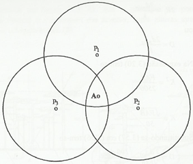

Figura 4: Exemplificação de dependência entre pontos amostrais distintos.

Idealmente, a solução é encontrar uma distância mínima entre ACAs que garanta que nenhuma árvore seja incluída em duas amostras. Péllico Netto & Brena (1997) propõem que essa distância deve ser pelo menos duas vezes o raio crítico $R_c$ da maior árvore da floresta. O desenvolvimento é dado a seguir:

$$K = \frac{DAP_i}{R_i}$$

$$R_i = \frac{DAP_i}{K}$$

Presumindo o dobro da distância crítica da maior árvore, então

$$2R_c = \frac{2DAP_{max}}{K}$$

Assumindo que $2R_c = D$,

$$D = \frac{2DAP_{max}}{K}$$

Do resultado de $FAB$, tem-se que

$$K^2 = \frac{FAB}{2500}$$

$$K = \frac{\sqrt{FAB}}{50}$$

Agora, substituindo $K$, tem-se que

$$D = \frac{2DAP_{max}}{\sqrt{FAB}/50} = 2DAP_{max}\cdot\frac{50}{\sqrt{FAB}} = \frac{100\cdot DAP_{max}}{\sqrt{FAB}}$$

Onde $D$ é a distância mínima entre duas ACAs e $DAP_{max}$ é o maior diâmetro da população.

Tal método é adequado e garante que não exista interpolação de duas ACAs; no entanto, requer que seja conhecido o maior diâmetro da floresta. Na prática, é possível estipular um valor de $DAP_{max}$ apropriado que garanta cobrir o máximo da população. Assim, se terá a garantia de não sobreposição.

### 3.5.4 Declividade do terreno

O quarto problema trata do efeito da declividade do terreno (Figura 5). Embora impactante na seleção das árvores, é um problema pouco abordado, pois é automaticamente corrigido pelo Relascópio de Bitterlich. Note que o princípio de Bitterlich usa a distância horizontal até a árvore, mas dificilmente será o caso na prática. A própria diferença de altura entre o operador e a altura de medição do DAP já impacta nessa relação.

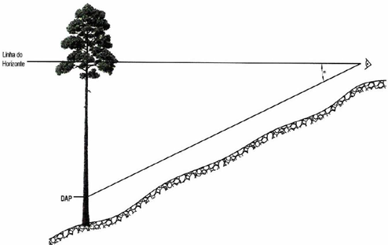

Figura 5: Comparação entre distância horizontal e inclinada na visada da relascopia.

Seja $D_h$ a distância horizontal e $D_i$ a distância inclinada a partir de um ângulo $\alpha$, então a relação entre $D_h$ e $D_i$ é dada por

$$D_h = D_i\cdot\cos(\alpha)$$

Agora veja que sempre é necessário manter a relação de abertura e distância, isto é,

$$\frac{DAP}{R} = \frac{d}{L} = K$$

Assumindo que $R_i$ é a distância horizontal $D_h$, então pode-se fazer a substituição

$$\frac{DAP}{D_h} = \frac{d}{L}$$

$$\frac{DAP}{D_i\cdot\cos(\alpha)} = \frac{d}{L}$$

$$\frac{DAP}{D_i} = \frac{d}{L}\cdot\cos(\alpha) = K\cdot\cos(\alpha)$$

Portanto, o fator de correção será de $\cos(\alpha)$. De forma prática, a interpretação é de que, para uma mesma distância $L$, a abertura deve ser de $d\cdot\cos(\alpha)$. Como $\cos(\alpha)$ está sempre no intervalo $-1 \leq \cos(\alpha) \leq 1$, então qualquer declividade resultará em uma diminuição da abertura $d$ para uma mesma distância $L$, tal qual está implementado no tambor giratório do Relascópio de Bitterlich.

Para encontrar o ângulo de abertura corrigido, basta utilizar a relação fundamental. Note que no Resultado 6, se a declividade for 0 ($\alpha = 0$), então não há correção, pois $\cos(0) = 1$.

$$2\sin\left(\frac{\theta_c}{2}\right) = K\cdot\cos(\alpha)$$

$$\sin\left(\frac{\theta_c}{2}\right) = \frac{K\cdot\cos(\alpha)}{2}$$

$$\frac{\theta_c}{2} = \sin^{-1}\left(\frac{K\cdot\cos(\alpha)}{2}\right)$$

$$\theta_c = 2\cdot\sin^{-1}\left(\frac{K\cdot\cos(\alpha)}{2}\right)
\tag{6}$$

Onde $\theta_c$ é o ângulo de abertura corrigido e $\alpha$ é o ângulo de declividade do terreno.

## 3.6 Seleção do fator de área basal

A determinação do Fator de Área Basal adotado é critério do operador. Naturalmente, um fator de área basal menor aumentará as chances de uma árvore ser amostrada, porém sua contribuição será menor. Portanto, a escolha do FAB dependerá sobretudo da variação dendrométrica e da densidade da floresta (MACHADO; FIGUEIREDO FILHO, 2005).

Alguns autores discutem sobre o número ideal de árvores que devem compor uma ACA, variando entre 10 e 30 árvores por ACA. Uma sugestão do próprio manual do Relascópio de Espelhos é algo entre 20 e 30 árvores, portanto deve ser selecionada uma banda que reproduza uma quantia próxima disso em campo.

## 3.7 Princípio da probabilidade proporcional ao tamanho

Com as devidas explicações do método de Bitterlich, resta ainda abordar um tópico teórico sobre o método, o motivo de ser considerado não só um método de área variável, mas um método com probabilidade proporcional ao tamanho (*probability proportional to size* - PPS) da árvore.

Em parcelas circulares de área fixa, é comum imaginar um ponto no espaço do qual é lançado um raio, e todas as árvores contidas nesse raio são selecionadas. Entretanto, esse mesmo raciocínio pode ter outro ponto de vista, onde esse mesmo raio é traçado do centro de cada árvore, de forma que cada árvore possua sua própria parcela circular, porém todas de mesma área. Analogamente, farão parte da amostra todas as árvores cuja parcela englobar o ponto do observador (Figura 6).

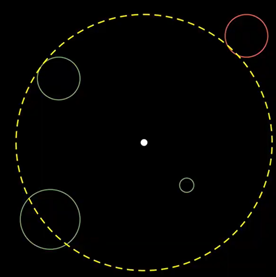

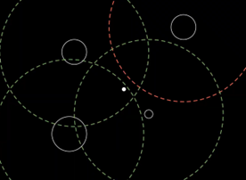

Figura 6: Representação da parcela circular sob outro ponto de vista.

Entretanto, como no método de Bitterlich as árvores possuem parcelas de forma que equivalem ao $FAB$, fica evidente que cada árvore terá uma parcela de raio proporcional ao seu tamanho, tal que a área basal dessa parcela contendo uma única árvore tenha sempre área basal igual a $FAB\ \text{m}^2/\text{ha}$ (Figura 7). Ou seja, árvores menores possuem menor chance de serem amostradas, daí o termo probabilidade proporcional ao tamanho.

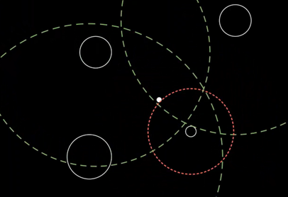

Figura 7: Área de cada parcela proporcional ao tamanho da árvore.

## 3.8 Relascópio de Bitterlich e novos aparelhos

O Relascópio de Espelho é o instrumento mais apropriado para realização da relascopia. Ele é composto, entre outros componentes, de um ponto de mira e um conjunto de espelhos, que permitem que o usuário visualize ao mesmo tempo a árvore e um calibre já ajustado para o Fator de Área Basal desejado. Esse calibre é chamado de banda, e o relascópio possui por padrão diversas bandas para vários FABs, como banda 1, 2 ou 4 para fatores 1, 2 e 4, respectivamente. Tais bandas são faixas enroladas em um tambor no interior do instrumento, que permite correção instantânea da declividade.

Além da contagem angular, o Relascópio de Espelho também acumula diversas funções. Uma delas é o estabelecimento de distâncias predefinidas, similar aos hipsômetros, pois para certas distâncias, 20, 25, 30 m etc., o relascópio possui escalas de altura. Isso permite uma ampla gama de estimativas, como medidas de diâmetros para diferentes alturas da árvore, sem necessidade de abate dos indivíduos, medidas de altura de árvores, obtenção da altura formal, altura média do povoamento e declividade do terreno.

Além do Relascópio de Espelho, existe também a versão eletrônica chamada Telerelascópio, que possui uma base fixa de apoio e permite uma estimativa digital da ACA. Além do Telerelascópio, há também um instrumento chamado *Criterion*, capaz de realizar as mesmas funções do Relascópio de Espelho.

## 3.9 Utilização em inventários

A relascopia pode ser utilizada como qualquer outro método de área fixa em inventários florestais. Afinal, se em um método de área fixa, diga-se de parcela retangular, existe uma estimativa para se calcular a área basal ou volume da parcela, então também na relascopia essas quantidades são estimadas pelas fórmulas apresentadas anteriormente, e as estimativas da população vão depender do processo amostral adotado.

Tomando-se como exemplo a amostragem casual simples, é intuitivo adotar a média amostral como estimador da população. Caso fossem lançadas 15 ACAs em uma floresta, a estimativa da área basal por hectare da floresta seria calculada como

$$\bar{G} = \frac{1}{m}\sum_{j=1}^{m} G_j = \frac{1}{15}\sum_{j=1}^{15} G_j$$

Onde $\bar{G}$ é a área basal média da população, em $\text{m}^2/\text{ha}$, $m = 15$ é o tamanho da amostra, e $G_j$ é a estimativa da área basal da $j$-ésima ACA realizada.

No caso de amostragem casual simples, a fórmula de $\bar{G}$ pode ser generalizada para

$$\bar{G} = \frac{1}{m}\sum_{j=1}^{m} n_j FAB = \frac{FAB}{m}\sum_{j=1}^{m} n_j$$

Entretanto, o estimador mais adequado para a área basal média vai depender do processo amostral adotado.

Em comparação com métodos de área fixa, o método de Bitterlich fornece estimativas confiáveis para área basal. A estimativa do número de árvores por hectare pode ser diferente da estimativa em área fixa, pois, como discutido anteriormente, essa última introduz uma seleção sistemática de indivíduos com base no DAP, algo que não ocorre com a relascopia. Como consequência, se a banda utilizada na relascopia for pequena o suficiente, possibilitará a inclusão de árvores que nunca seriam amostradas no método de área fixa. Ainda assim, a maior parte dos trabalhos da área aponta consistência nas medições para a maioria dos casos (MIRANDA *et al*., 2015).

## 3.10 Vantagens e desvantagens

A principal vantagem da relascopia é, sem dúvida, a economia de tempo e a agilidade para obtenção de estimativas do povoamento. Entretanto, outras vantagens são evidentes:

- Minimização ou eliminação dos erros provenientes da demarcação incorreta da superfície das unidades amostrais;
- Flexibilidade para adoção de um fator de área basal apropriado, de forma a não superar um número muito elevado de árvores da amostra;
- As estimativas das variáveis dendrométricas podem ser obtidas através de qualquer aparelho óptico, de baixo custo, não necessariamente o relascópio.

Entretanto, também devem ser citadas desvantagens do método:

- A existência de um sub-bosque abundante pode aumentar erros de inclusão visual das árvores;
- Qualquer defeito no aparelho ou na abertura de visada tornará a estimativa viesada, dada a inclusão de árvores que não deveriam ser incluídas ou vice-versa;
- A utilização desse método como unidades permanentes é difícil, pois a mudança dos indivíduos ao longo do tempo causará mudança na seleção de indivíduos ao longo do tempo.

# 4 Conclusão

O método de Bitterlich, formalizado através da relascopia, representa um dos marcos mais relevantes na história da mensuração florestal. Sua principal virtude reside na simplicidade operacional combinada com rigor estatístico, permitindo a estimativa eficiente da área basal, número de árvores e volume por hectare sem a necessidade de parcelas físicas ou medições complexas. Fundamentado em princípios geométricos e no conceito de probabilidade proporcional ao tamanho (PPS), o método proporciona estimativas robustas, especialmente em florestas formadas por indivíduos de médio a grande porte.

A evolução dos instrumentos, desde a Barra de Bitterlich até o Relascópio de Espelho e o Telerelascópio, permitiu superar limitações operacionais, como a declividade do terreno, tornando a técnica ainda mais acessível e confiável. Ao longo das últimas décadas, o método foi amplamente estudado, validado e aplicado em diferentes contextos florestais, demonstrando não apenas sua aplicabilidade prática, mas também sua consistência teórica.

Contudo, a aplicação correta da relascopia requer do profissional florestal domínio técnico, atenção a detalhes de campo, como sobreposição de árvores, independência entre pontos e seleção do fator de área basal, e uma compreensão clara dos pressupostos estatísticos envolvidos. Em síntese, o legado de Bitterlich permanece atual, sendo a relascopia uma ferramenta indispensável na prática do manejo florestal, conciliando precisão, eficiência e economia de recursos.

# 5 Referências

FINGER, C.A.G. **Apostila de Biometria Florestal**. Santa Maria: UFSM/CEPEF/FATEC, 2006. 284 p.

PELLICO NETO, S.; BRENA, D.A. **Inventário florestal**. Curitiba: [s.l.], 1997. 316 p.

MACHADO, S.A.; FIGUEIREDO FILHO, A. **Dendrometria**. 2. ed. Guarapuava: Unicentro, 2005. 316 p.

MIRANDA, D.L.C. *et al.* Precisão e eficiência relativa de métodos de amostragem em teca. **Pesquisa Florestal Brasileira**, v. 35, n. 83, 2015.

SILVA, G.F. *et al.* **Padronização da simbologia em mensuração florestal e manejo florestal**. Alegre: Edição dos Autores, 2022. 63 p.